# RQ1

Nadiia Honcharenko

## R Markdown

```r
library(caret)
library(randomForest)
library(e1071)
library(ggplot2)
library(dplyr)
library(tidyverse)

# Creating of useful functions
create_conf_matrix <- function(refLabels, predictLabels, positiveLabel){
  conf_matrix <- confusionMatrix(
    refLabels, # reference labels
    predictLabels, # predicted labels
    positive = positiveLabel, # label that corresponds to a "positive" results (optional)
    dnn = c("actual", "predicted") # names of the confusion matrix dimensions  (optional)
  )
  return (conf_matrix)
}

get_evaluation <- function(refLabels, predictLabels, positiveLabel){
  conf_matrix <- create_conf_matrix(refLabels, predictLabels, positiveLabel)
  conf_matrix
  print(conf_matrix$overall["Accuracy"])
  print(conf_matrix$byClass["Sensitivity"])
  print(conf_matrix$byClass["Specificity"])
  ## todo add another evaluations
}

# Data preparation
cleared_supermarket_data <- read_csv("D:/Data-Science-with-R/Data-Science-with-R/Input Dataset/Cleaned Dataset/Supermarket_DataCleaned.csv")
cleared_supermarked_tbl <- tbl_df(cleared_supermarket_data)

shop_ordered_slice <- select(cleared_supermarked_tbl, 3,23,4,24,5,25,6,26,7,27) %>%
  bind_cols(cleared_supermarked_tbl[,8:10], cleared_supermarked_tbl[,28])

distance_separator <- mean(shop_ordered_slice[["avg_distance_to_all_shops"]])
price_separator <- mean(shop_ordered_slice[["avg_purchased_product_price_allShops"]])

set.seed(101)
row_count <- nrow(shop_ordered_slice)
train_index <- sample(row_count, round(0.7 * row_count))

rq1_dataset <- shop_ordered_slice %>%
  select(11,12,13,14)%>%
  mutate(label=factor(ifelse((max_dist_to_custSel_shops > distance_separator & avg_purchased_product_price_allShops > price_separator), "y", "n"))) %>%
  rename(average_distance = avg_distance_to_all_shops,
         average_price = avg_purchased_product_price_allShops) %>%
  select(average_distance, average_price, label) %>%
  mutate(in_train = if_else(row_number() %in% train_index, TRUE, FALSE))


# splitting data to test and training
train_ds <- rq1_dataset %>%
  filter(in_train) %>%
  select(average_distance, average_price)
y_train <- rq1_dataset %>%
  filter(in_train) %>%
  pull(label)
y_test <- rq1_dataset %>%
  filter(!in_train) %>%
  pull(label)

test_ds <- rq1_dataset %>%
  filter(!in_train) %>%
  select(average_distance, average_price)

create_random_forest_fit <- function(ntree){
  fit <- randomForest(y_train ~ ., cbind(train_ds,y_train), ntree=ntree)
  return(fit)
}

draw_plot_for_classes <- function(data, predicted, title){
  plot_data <- data %>% mutate(label = as.factor(predicted))
  ggplot(plot_data, aes(average_distance, average_price, color = label)) +
    geom_point(alpha = .75) +
    xlab("Distance") + ylab("Price") +
    # geom_smooth(method=lm) +
    coord_trans(x ="sqrt", y="log10") +
    theme_bw()+
    ggtitle(title)
}

classify_with_fit <- function(fit, title){
  train_predicted <- predict(fit, train_ds, type = "class")
  print("Evaluation for the training")
  get_evaluation(y_train, train_predicted, "y")
  predicted <- predict(fit, test_ds, type = "class")
  print("Evaluation for the tests")
  get_evaluation(y_test, predicted, "y")
  draw_plot_for_classes(test_ds, predicted, title)
}

#plot(test_ds, col = c("red","blue")[as.numeric(yclass_test)], pch = 20, cex = 1.3)
```

## Classification

**1) Classification with SVM**

```r
#tune SVM
tuneSvm <- tune(svm, y_train ~ ., data = cbind(train_ds,y_train), ranges = list(gamma = 2^(-1:1)),
     cost = 2^(2:4), tunecontrol = tune.control(sampling = "fix"))
summary(tuneSvm)
```

```
##
## Parameter tuning of 'svm':
##
## - sampling method: fixed training/validation set
##
## - best parameters:
##  gamma
##      2
##
## - best performance: 0.05217947
##
## - Detailed performance results:
##   gamma      error dispersion
## 1   0.5 0.05977566         NA
## 2   1.0 0.05565810         NA
## 3   2.0 0.05217947         NA
```

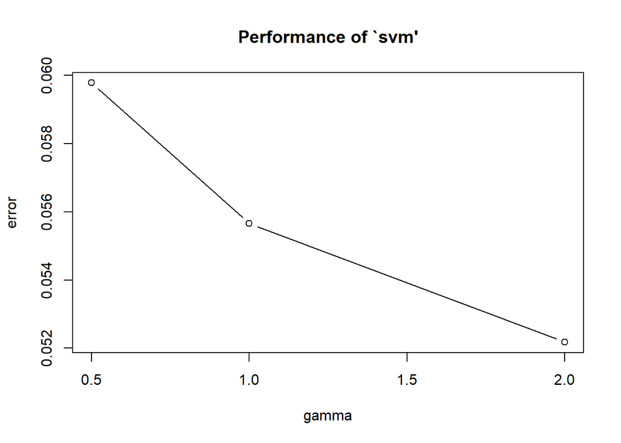

```r
plot(tuneSvm)
```

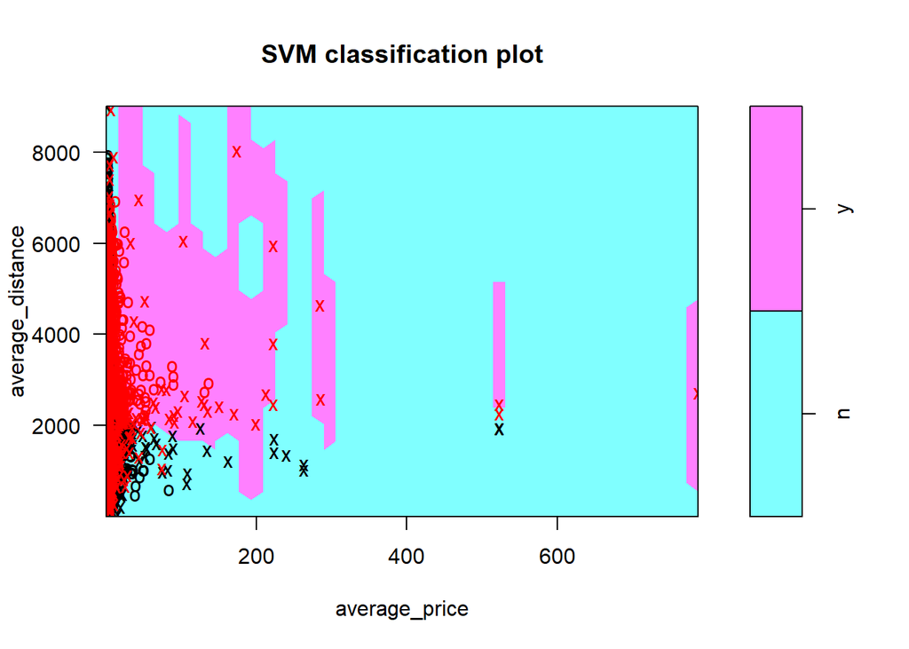

```r
#classify with best params
svmFit <- svm(y_train ~ ., data = cbind(train_ds,y_train), kernel = "radial",
           cost = 1, gamma = 0.5,
           scale=TRUE, cachesize=95)

plot(svmFit, cbind(train_ds,y_train))
```

```r
classify_with_fit(svmFit, "SVM classification")
```

```
## [1] "Evaluation for the training"
##  Accuracy
## 0.9359618
## Sensitivity
##   0.9160181
## Specificity
##   0.9389616
## [1] "Evaluation for the tests"
##  Accuracy
## 0.9375449
## Sensitivity
##   0.9224211
## Specificity
##   0.9397957
```

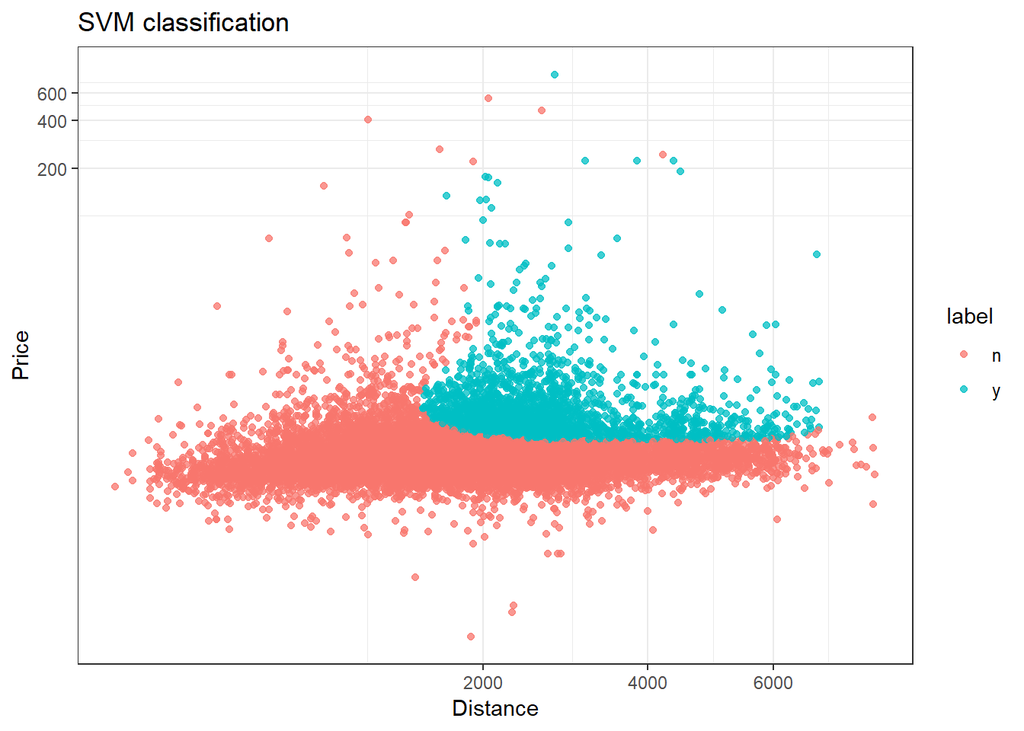

**2) Classification with K-nearest neighbor** *Why k-NN?:* Generally runs K-nearest neighbor algorithm slower and has lower accuracy in comparision with SVM, but it’s got some nice practical qualities. It’s easy to train, because k-NN is ranked as a lazy algorithmus and there’s no training. Consequently it’s easy to use, and it’s easy to understand the results. However k-NN classification is used more in the industry than an academic might think.

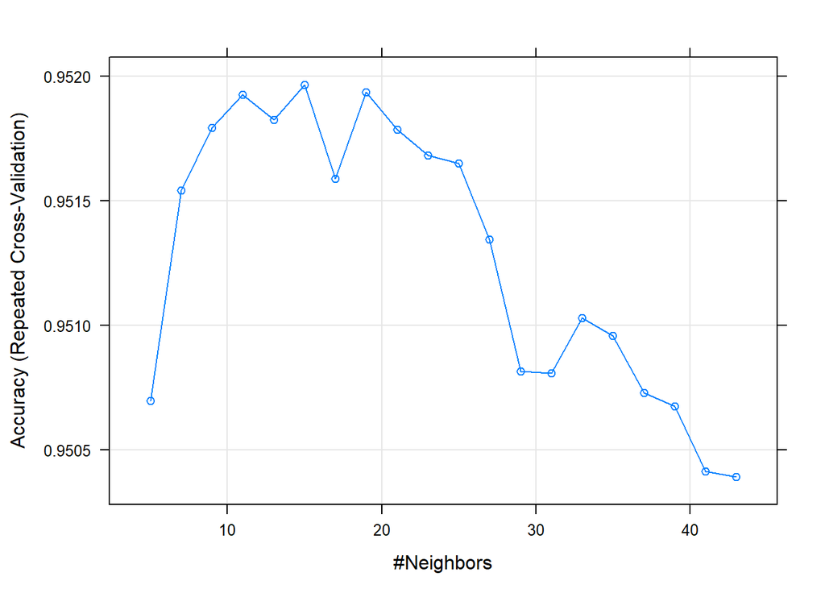

```r
# train knn classifier

set.seed(400)
ctrl <- trainControl(method="repeatedcv",repeats = 3) #,classProbs=TRUE,summaryFunction = twoClassSummary)
knnTrain <- train(y_train ~ ., data = cbind(train_ds,y_train), method = "knn",
                trControl = ctrl, preProcess = c("center","scale"), tuneLength = 20)
plot(knnTrain)
```

```r
#classify with best params
knnFit <- knn3(train_ds, y_train, k = 15)
classify_with_fit(knnFit, "KNN classification")
```

```
## [1] "Evaluation for the training"
##  Accuracy
## 0.8877556
## Sensitivity
##   0.9076433
## Specificity
##   0.8861591
## [1] "Evaluation for the tests"
##  Accuracy
## 0.8771881
## Sensitivity
##   0.8628571
## Specificity
##   0.8782279
```

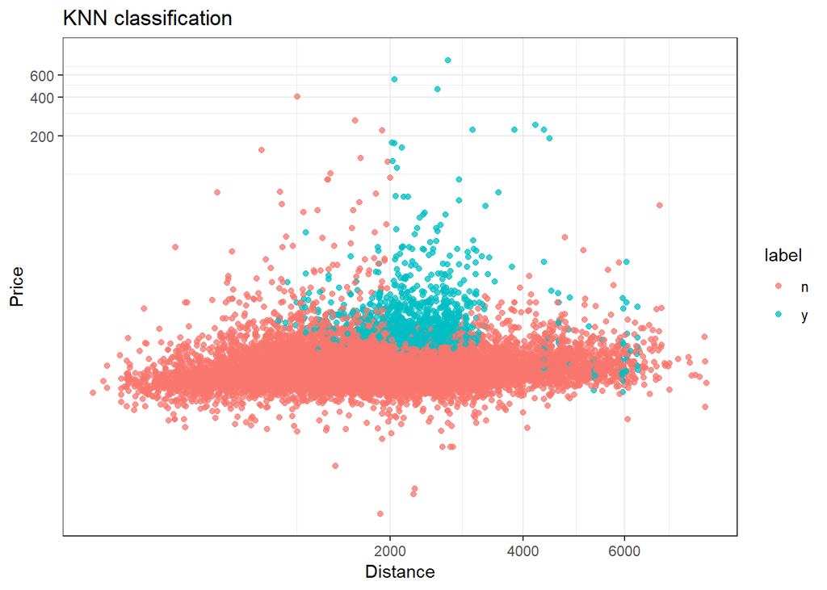

**2) Classification with Random Forest** *Why Random Forest?:* In comparision with k-NN classification, Random Forest is a great algorithm to train early in the model development process, to see how it performs. This algorithm is also very hard to beat in terms of performance. And on top of that, RF can handle a lot of different feature types, like binary, categorical and numerical.

```r
randomFit <- randomForest(y_train ~ ., cbind(train_ds,y_train), ntree=500)
classify_with_fit(randomFit, "Random Forest")
```

```
## [1] "Evaluation for the training"
## Accuracy
##        1
## Sensitivity
##           1
## Specificity
##           1
## [1] "Evaluation for the tests"
##  Accuracy
## 0.9560992
## Sensitivity
##   0.8731487
## Specificity
##    0.973272
```

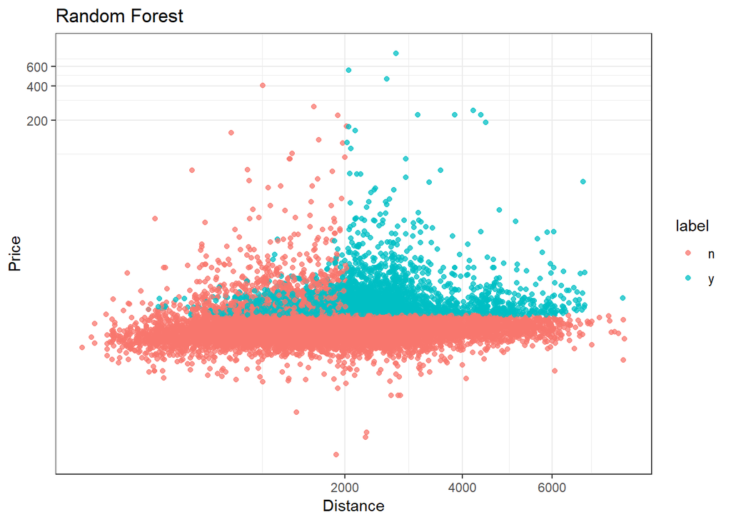